# Poročilo pri predmetu Analiza podatkov s programom R

Valentina Pucer

# Izbira teme

Za tematiko svoje seminarske naloge sem si izbrala analizo podatkov naravnih nesreč v Združenih državah Amerike iz radovednosti, da izvem, v kakšnem obsegu so naravne nesreče na drugi strani sveta, koli denarne škode povzročijo..ipd.Naloge se se lotila tako, da sem podatke iz spletne strani prenesla v program Microsoft Office Excel Worksheet in oblikovala tabelo, ki se od originalne razlikuje v tem, da je nekaj odvečnih podatkov odstranjenih, nekaj dodanih in urejenih. Drugo tabelo sem uvozila iz spletne strani in jo tudi preuredila. Nanaša se na podatke o številu smrtnih žrtev v dani naravni nesreči. S pomočjo teh dveh tabel bom nato izdelala zemljevid.

# Obdelava, uvoz in čiščenje podatkov

Podatke sem uvozila v obliki .csv in direkt s spletne strani:

- “https://en.wikipedia.org/wiki/List_of_natural_disasters_in_the_United_States”
- “https://en.wikipedia.org/wiki/List_of_disasters_in_the_United_States_by_death_toll”

Pri prvem uvozu sem tabeli uredila stolpce,tako da sem zamenjala njihov vrstni red, odvečni zadnji stolpec prvotne tabele pobrisala. Pobrisala sem tudi posamezne odvečne znake, ki so se pojavili v tabeli. Urediti sem morala tudi števila npr. jih iz nizov dati v as.numeric. Pri filtraciji podatkov sem glede na stolpec Škoda ocenila tip(stopnjo) škode in temu dodala nov stolpec.

Spremenljivke pri prvi tabeli:

- ta dogodek(imenska spremenljivka)
- lokacija(imenska spremenljivka ….(za zemljevid))
- leto, v katerem se je nesreča pripetila (številska spremenljivka)
- tip naravne nesreče, ki se je pripetila (imenska spremenljivka)
- število smrtnih žrtev(urejenostna smremenljivka (številska), HUDO, NI HUDO)
- denarna škoda(urejenostna,….VELIKA ŠKODA, MANJŠA ŠKODA)

| Leto | Lokacija | Tip.naravne.nesreče | Dogodek | Smrtne.žrtve | Škoda | Stopnja_skode |
| --- | --- | --- | --- | --- | --- | --- |
| 2015 | Texas, Kansas, Oklahoma | Flood | 2015 Texas-Oklahoma floods | 46 | NA | NA |
| 2015 | Carolinas | Flood | October 2015 North American Storm Complex | 25 | 1e+09 | Manjša |
| 2015 | Utah | Flood | 2015 Utah floods | 20 | NA | NA |
| 2015 | Okanogan County, Washington | Wild fire | Okanogan Complex fire | 3 | NA | NA |
| 2014 | Oso, Washington | Mudflow | 2014 Oso mudslide | 43 | NA | NA |
| 2014 | Nebraska, Louisiana,Oklahoma, Illinois, Florida,North Carolina | Tornado | April 2014 tornado outbreak | 35 | 1e+09 | Manjša |

V drugem uvozu sem večidel stolpcev pobrisala. Ostala sta le dva prvotna in tretji, ki se nanaša na število smrtnih žrtev pri neki naravni nesreči(stopnja smrti oz.umrljivosti).Tudi tukaj sem morala številske podatke prečistiti na ta način, da sem se znebila posameznih odvečnih znakov in jih iz nizov pretvorila v številski podatek, s katerim sem potem lahko upravljala.

[output not shown]

Ideja za napoved podatkov naslednji fazi: Iz prve tabele odvisnost ocenjene škode od lokacije naravne nesreče (razvitost območja) ali pa vpliv tipa naravne nesreče na stopnjo denarje škode. Lahko bi sklepala, da bodo posamezne manj razvite lokacije, kjer so se naravne nesreče zgodile, imele več denarne škode, ker imajo manj sredstev za vlaganje v zavarovanje pred temi dogodki (protipoplavni nasipi, protipotresne zgradbe), s pomočjo katerih je škoda manjša. Še vedno pa imajo vpliv na stopnjo denarne škode tudi drugi dejavniki, saj ne morem enačiti hurikana s poplavo.

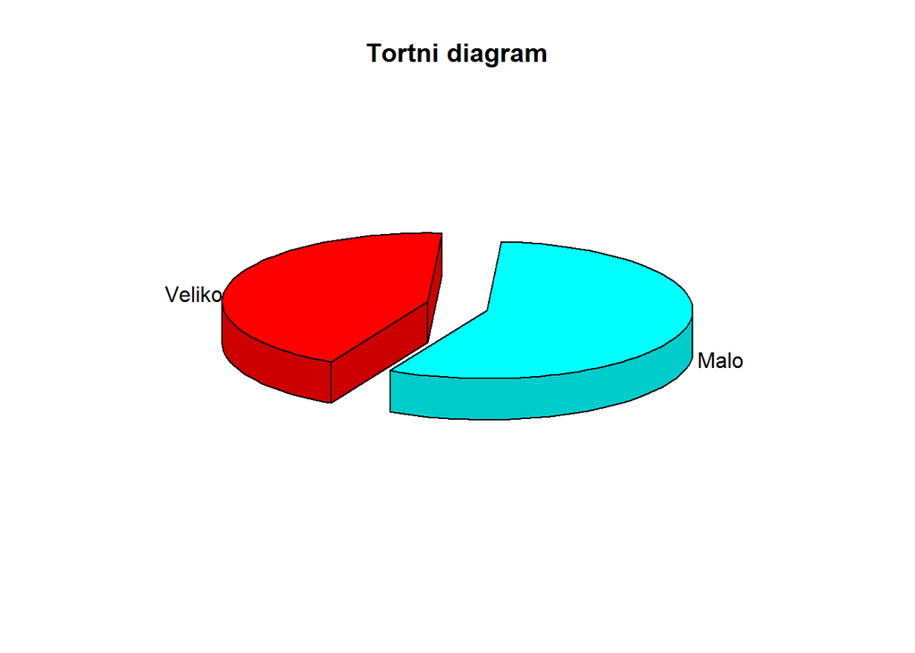

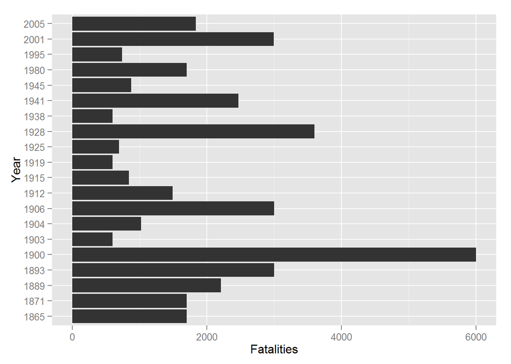